# dev_blocks_needed

N.M. Tarr

2023-10-03

# Purpose

This document defines and demonstrates a function that returns a data frame of blocks where the species was predicted to occur by GAP or eBird but the NCBA has yet to acquire observations.

# Definition

```r
blocks_needed
```

```
## function (species, source, season, database, project, observations = NULL)
## {
##     breedates <- get_breeding_dates(species, day_year = TRUE)
##     fields <- c("ID_BLOCK_CODE", "ID_EBD_NAME", "PRIORITY")
##     blocks_sf <- get_blocks(spatial = TRUE, fields = fields)
##     if (is.null(observations) == TRUE) {
##         obs <- get_observations(species = species, database = database,
##             project = project) %>% to_EBD_format()
##     }
##     else {
##         obs <- observations
##     }
##     if (season %in% c("summer", "SUMMER", "breeding", "BREEDING") ==
##         TRUE) {
##         within = TRUE
##     }
##     if (season %in% c("winter", "WINTER", "wintering", "WINTERING") ==
##         TRUE) {
##         within = FALSE
##     }
##     observed <- blocks_observed_in(observations = obs, start_day = breedates[[1]],
##         end_day = breedates[[2]], within = within, breeding_categories = c("C4",
##             "C3", "C2", "C1", ""))$atlas_block
##     predicted <- get_predicted_presence(species, source, season)$ID_BLOCK_CODE
##     needed <- setdiff(predicted, observed)
##     needed_sf <- filter(blocks_sf, ID_BLOCK_CODE %in% needed ==
##         TRUE)
##     needed_sf$needed <- "needed"
##     return(needed_sf)
## }
```

# Usage

Running the function returns a data frame with records for atlas blocks where the species was predicted to occur but has not yet been observed. The data frame also has simple features so that it can be used in a map.

```r
species <- "Loggerhead Shrike"

# Get a data frame of blocks that need observations
needed_sf <- blocks_needed(species = "Loggerhead Shrike",
                           source = "GAP", season = "summer",
                           database = "AtlasCache", project = "EBIRD_ATL_NC",
                           observations = NULL)
# Print
print(head(needed_sf, 5))
```

```
## Simple feature collection with 5 features and 9 fields
## Geometry type: POLYGON
## Dimension:     XY
## Bounding box:  xmin: -80.50001 ymin: 34.25002 xmax: -78.12501 ymax: 36.37502
## Geodetic CRS:  WGS 84
##         _id ID_BLOCK_CODE    ID_EBD_NAME      NW_X     NW_Y PRIORITY      SE_X
## 1 34078E6NW     34078E6NW Abbottsburg NW -78.75001 34.62502        0 -78.68751
## 2 34078C2CW     34078C2CW        Acme CW -78.25001 34.33335        0 -78.18751
## 3 36078C2NE     36078C2NE       Afton NE -78.18751 36.37502        0 -78.12501
## 4 34078C2SW     34078C2SW        Acme SW -78.25001 34.29169        0 -78.18751
## 5 35080H4NW     35080H4NW     Advance NW -80.50001 36.00002        0 -80.43751
##       SE_Y                            wkt needed
## 1 34.58335 POLYGON ((-78.68751 34.5833... needed
## 2 34.29169 POLYGON ((-78.18751 34.2916... needed
## 3 36.33335 POLYGON ((-78.12501 36.3333... needed
## 4 34.25002 POLYGON ((-78.18751 34.2500... needed
## 5 35.95835 POLYGON ((-80.43751 35.9583... needed
```

The resulting data frame can be drawn up as a map.

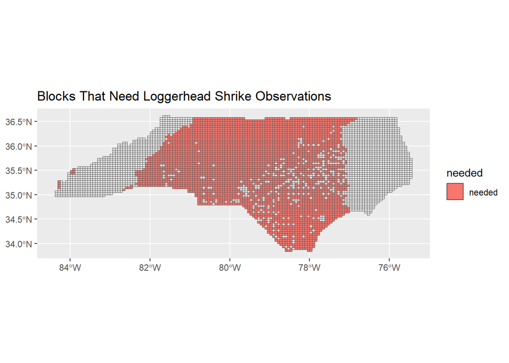

```r
# Get a blocks data frame with simple features
fields <- c("ID_BLOCK_CODE", "ID_EBD_NAME")
blocks_sf <- get_blocks(spatial = TRUE, fields = fields)

# Plot the spatial data frame
ggplot() +
  geom_sf(data = blocks_sf) +
  geom_sf(data = needed_sf, aes(fill = needed)) +
  ggtitle(str_interp("Blocks That Need ${species} Observations"))
```

The result can also be used in a map with multiple layers. For example, it can be drawn below a layer showing the highest reported breeding category per block.

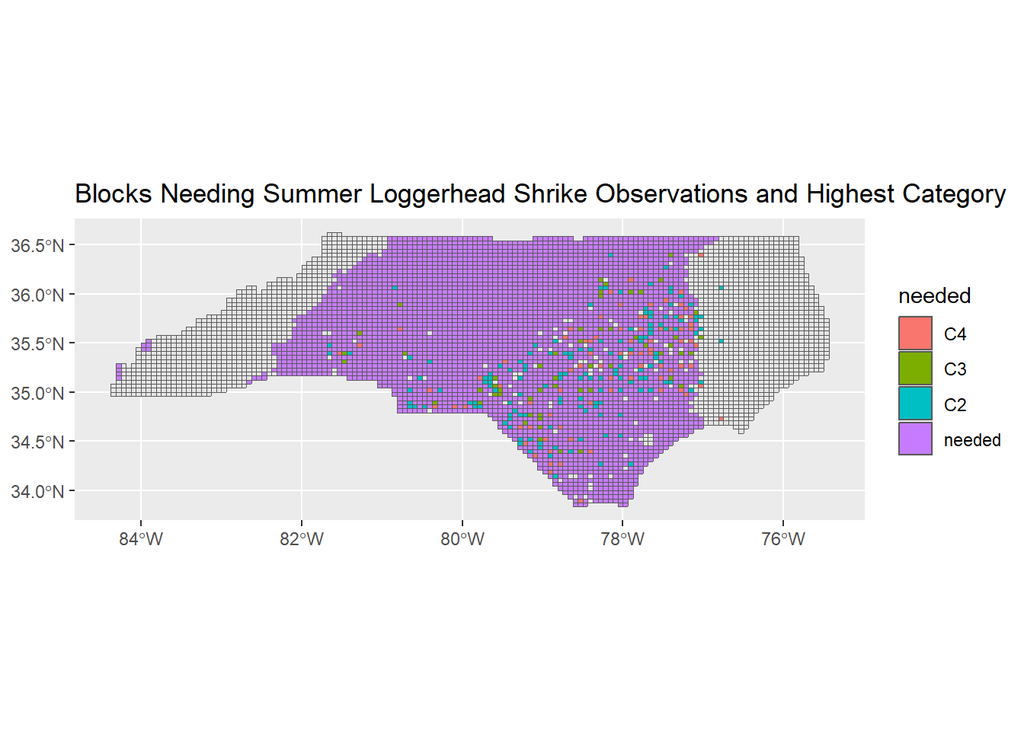

```r
# Get the highest breeding category code per block
highest_sf <- highest_category(species) %>%
  drop_na()

# Plot the spatial data frame
ggplot() +
  geom_sf(data = blocks_sf) +
  geom_sf(data = needed_sf, aes(fill = needed)) +
  geom_sf(data = highest_sf, aes(fill = highest_category)) +
  ggtitle(str_interp("Blocks Needing Summer ${species} Observations and Highest Category"))
```

Running the get_observations function can be slow, but it can be run ahead of time and the results passed to blocks_needed in order to speed up the runtime.

```r
species <- "Red-breasted Nuthatch"
# Get a data frame of observations
obs <- get_observations(species = species, database = "AtlasCache",
                        project = "EBIRD_ATL_NC") %>%
      to_EBD_format()
```

Here, a data frame is passed to the function to find blocks needing winter observations.

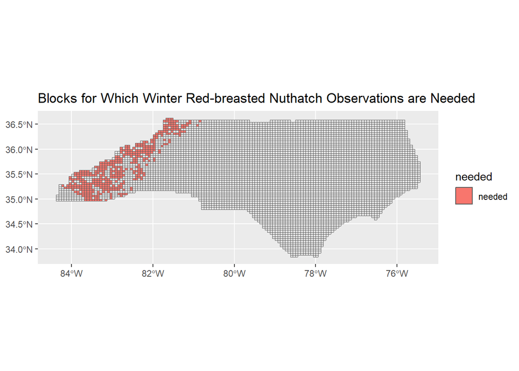

```r
# Get a dataframe of blocks that need observations
needed_sf <- blocks_needed(species = species, source = "GAP", season = "winter",
                           database = database, observations = obs)

# Plot the spatial data frame
ggplot() +
  geom_sf(data = blocks_sf) +
  geom_sf(data = needed_sf, aes(fill = needed)) +
  ggtitle(str_interp("Blocks for Which Winter ${species} Observations are Needed"))
```

# Tests

This function relies almost entirely on other ncba_functions that were tested elsewhere, thus formal tests are not necessary. However, various species can be explored to assure that results are as they should be.

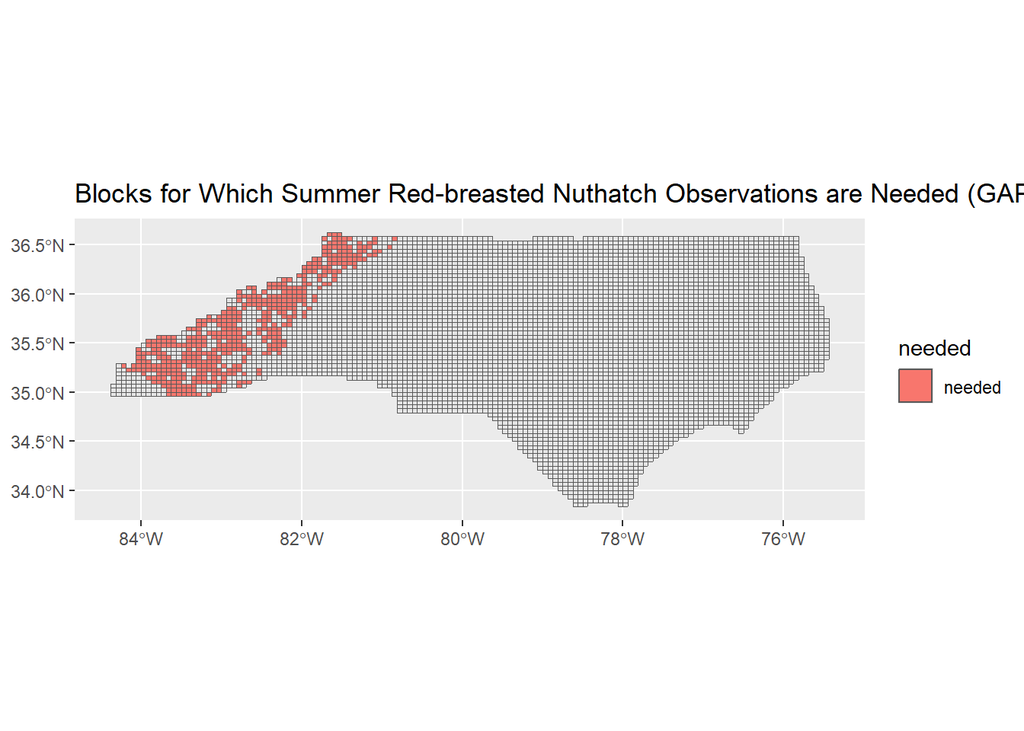

```r
# Get a dataframe of blocks that need observations
needed_sf <- blocks_needed(species = "Red-breasted Nuthatch",
                           source = "GAP",
                           season = "summer",
                           database = database,
                           project = "EBIRD_ATL_NC",
                           observations = obs)

# Plot the spatial data frame
ggplot() +
  geom_sf(data = blocks_sf) +
  geom_sf(data = needed_sf, aes(fill = needed)) +
  ggtitle("Blocks for Which Summer Red-breasted Nuthatch Observations are Needed (GAP)")
```

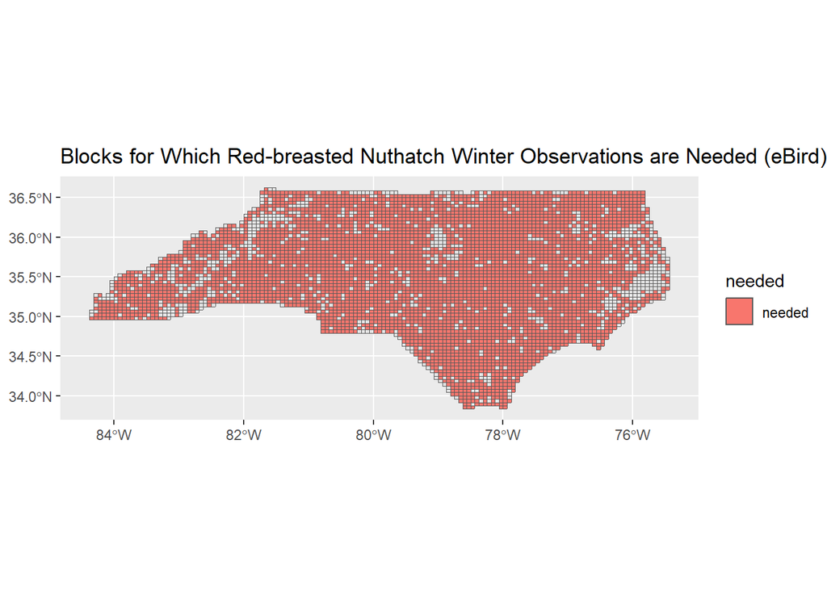

```r
# Get a dataframe of blocks that need observations
needed_sf <- blocks_needed(species = "Red-breasted Nuthatch",
                           source = "eBird",
                           season = "wintering",
                           database = database,
                           project = "EBIRD_ATL_NC",
                           observations = obs)

# Plot the spatial data frame
ggplot() +
  geom_sf(data = blocks_sf) +
  geom_sf(data = needed_sf, aes(fill = needed)) +
  ggtitle("Blocks for Which Red-breasted Nuthatch Winter Observations are Needed (eBird)")
```

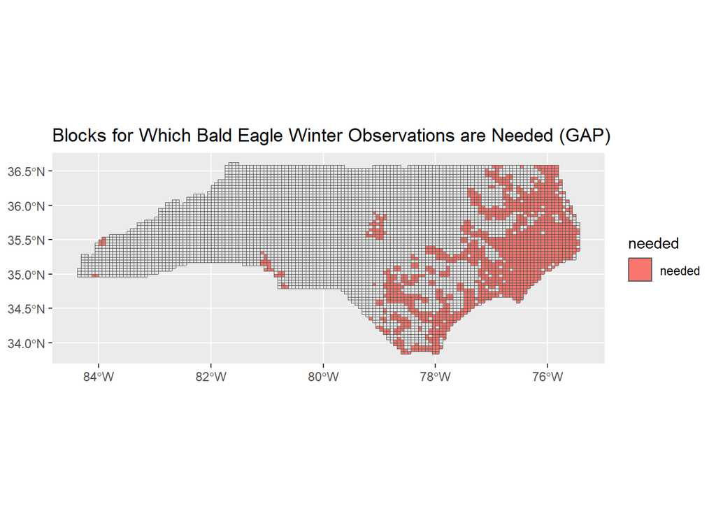

```r
# Get a data frame of blocks that need observations
needed_sf <- blocks_needed(species = "Bald Eagle",
                           source = "GAP",
                           season = "winter",
                           database = database,
                           project = NULL,
                           observations = obs)

# Plot the spatial data frame
ggplot() +
  geom_sf(data = blocks_sf) +
  geom_sf(data = needed_sf, aes(fill = needed)) +
  ggtitle("Blocks for Which Bald Eagle Winter Observations are Needed (GAP)")
```

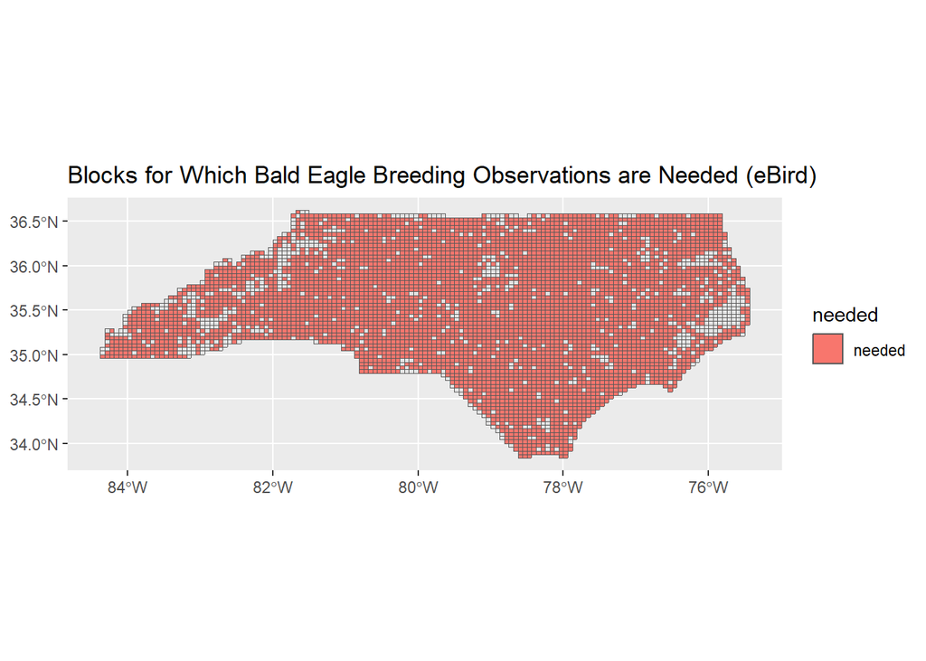

```r
# Get a dataframe of blocks that need observations
needed_sf <- blocks_needed(species = "Bald Eagle",
                           source = "eBird",
                           season = "breeding",
                           database = database,
                           project = "EBIRD_ATL_NC",
                           observations = obs)

# Plot the spatial data frame
ggplot() +
  geom_sf(data = blocks_sf) +
  geom_sf(data = needed_sf, aes(fill = needed)) +
  ggtitle("Blocks for Which Bald Eagle Breeding Observations are Needed (eBird)")
```

# Speed

Run the function 5 times and record the runtime

```r
time <- c()
for (i in 1:5) {
  time1 <- proc.time()
  blocks_needed(species = species, source = "GAP", season = "winter",
                           database = database, project = "EBIRD_ATL_NC",
                           observations = obs)
  t <- proc.time() - time1
  time[i] <- t["elapsed"]
}

# Print the descriptive statistics
print(summary(time))
```

```
##    Min. 1st Qu.  Median    Mean 3rd Qu.    Max.
##   0.950   0.960   0.970   1.214   1.140   2.050
```